# Financial Aids Influence on Graduation Rates

William Forero

# 1 - Introduction

Given the current uncertainty centered around the future of U.S Higher Education Financial Aid programs, it is appropriate to explore the relationship between the coverage of financial aid(percentage of students who receive aid) and the depth of financial aid (the amount of aid provided). One of the key metrics utilized for ascertaining an institutions “success” is graduation rate. Financial aid programs are generally offered with a purpose of bridging the gaps in access to higher education for students of different income levels.

# 2 - Importing The Data

```r
library(tidyverse)
```

**Importing the financial aid data**

```r
ipeds_fa2223 <- read.csv('https://raw.githubusercontent.com/william-forero/Data-607/refs/heads/main/sfa2223.csv')
```

How many rows and columns are included in the FA dataset?

```r
dim(ipeds_fa2223)
```

```
## [1] 5653  691
```

What does the data look like?

```r
head(ipeds_fa2223,5)
```

```
##   UNITID XSCUGRAD SCUGRAD XSCUGDGSK SCUGDGSK XSCUGNDGS SCUGNDGS XSCUGFFN
## 1 100654        R    5206         R     5201         R        5        R
## 2 100663        R   13032         R    12776         R      256        R
## 3 100690        R     228         R      228         R        0        R
## 4 100706        R    7169         R     6985         R      184        R
## 5 100724        R    3296         R     3296         R        0        R
##   SCUGFFN XSCUGFFP SCUGFFP XSCFA2 SCFA2 XSCFA2DG SCFA2DG XSCFA2ND SCFA2ND
## 1    1547        R      30      R  5206        R    5201        R       5
## 2    2172        R      17      R 13032        R   12776        R     256
## 3       0        R       0      R   228        R     228        R       0
## 4    1154        R      16      R  7169        R    6985        R     184
## 5     938        R      28      R  3296        R    3296        R       0
##   XSCFA1N SCFA1N XSCFA1P SCFA1P XSCFA11N SCFA11N XSCFA11P SCFA11P XSCFA12N
## 1       R   1547       R     30        R       0        R       0        R
## 2       R   2172       R     17        R       0        R       0        R
```

[output cut: 453 more lines]

**Importing the institutional characteristics**

```r
ipeds_inst2223 <- read.csv('https://raw.githubusercontent.com/william-forero/Data-607/refs/heads/main/hd2023.csv')
```

How many rows and columns are included in the Inst Characteristic Dataset?

```r
dim(ipeds_inst2223)
```

```
## [1] 6163   73
```

Takeaway: 6,163 rows and 73 columns in the 22-23 IPEDS Institutional Characteristic Dataset

What does the data look like?

```r
head(ipeds_inst2223,5)
```

```
##   UNITID                              INSTNM
## 1 100654            Alabama A & M University
## 2 100663 University of Alabama at Birmingham
## 3 100690                  Amridge University
## 4 100706 University of Alabama in Huntsville
## 5 100724            Alabama State University
##                                              IALIAS
## 1                                              AAMU
## 2                                               UAB
## 3 Southern Christian University  Regions University
## 4             UAH  University of Alabama Huntsville
## 5
##                             ADDR       CITY STABBR        ZIP FIPS OBEREG
## 1           4900 Meridian Street     Normal     AL      35762    1      5
## 2 Administration Bldg Suite 1070 Birmingham     AL 35294-0110    1      5
```

[output cut: 93 more lines]

**Importing the graduation rate data**

```r
ipeds_grad2223 <- read.csv('https://raw.githubusercontent.com/william-forero/Data-607/refs/heads/main/2223_IPEDS_CUSTOM_DATA_FILE.csv')
```

How many rows and columns are included in the Grad Rate Dataset?

```r
dim(ipeds_grad2223)
```

```
## [1] 1563   38
```

Takeaway: 1,563 rows and 38 columns in the 22-23 IPEDS Dataset

# 3 - Cleaning The Data

Using the data dictionary provided by IPEDS, I will first trim down each dataframe to the columns I intend to use for the project.

**Trimming down the FA columns**

Any counts below are for undergraduate, degree seeking students.

```r
fa_clean <- ipeds_fa2223 |>
  select(
    UNITID,                        # Inst ID
    tot_degr_ugrd    = SCUGDGSK,   # Tot Nbr Degr Seeking Ugrd
    nbr_awd_any_aid  = UDGAGRNTN,  # Nbr Ugrd Degr Awarded Any Aid
    tot_aid_awd      = UDGAGRNTT,  # Total aid awarded
    nbr_awd_pell_aid = UDGPGRNTN,  # Nbr Stdnts awarded Pell Grant
    tot_pell_awd     = UDGPGRNTT,  # Total Pell awarded
    nbr_awd_loans    = UDGFLOANN,  # Nbr Stdnts awarded Loans
    tot_loans_awd    = UDGFLOANT,  # Total Loans awarded
     ) |>
  mutate(
    # Creating columns that show what percent of degree seeking undergraduate
    # students received each type of aid
    perc_awd_any_aid = round(nbr_awd_any_aid  / tot_degr_ugrd , 2),
    perc_awd_pell    = round(nbr_awd_pell_aid / tot_degr_ugrd , 2),
    perc_awd_loans   = round(nbr_awd_loans    / tot_degr_ugrd , 2),
    # Creating columns that show the average aid package a student received
    avg_awd_any_aid  = round(tot_aid_awd      / nbr_awd_any_aid, 2),
    avg_awd_pell     = round(tot_pell_awd     / nbr_awd_pell_aid, 2),
    avg_awd_loans    = round(tot_loans_awd    / nbr_awd_loans, 2)
  )
head(fa_clean,5)
```

```
##   UNITID tot_degr_ugrd nbr_awd_any_aid tot_aid_awd nbr_awd_pell_aid
## 1 100654          5201            4326    50168163             3353
## 2 100663         12776            9645   101800616             4324
## 3 100690           228             216      473411              156
## 4 100706          6985            4790    47009835             1612
## 5 100724          3296            3159    32218913             2374
##   tot_pell_awd nbr_awd_loans tot_loans_awd perc_awd_any_aid perc_awd_pell
## 1     19363202          3050      20538077             0.83          0.64
## 2     26529097          5339      36242972             0.75          0.34
## 3       329636           165       1317500             0.95          0.68
## 4      7559208          2429      15645787             0.69          0.23
## 5     11648634          2563      21589661             0.96          0.72
##   perc_awd_loans avg_awd_any_aid avg_awd_pell avg_awd_loans
## 1           0.59        11596.89      5774.89       6733.80
## 2           0.42        10554.76      6135.31       6788.34
## 3           0.72         2191.72      2113.05       7984.85
## 4           0.35         9814.16      4689.33       6441.25
## 5           0.78        10199.09      4906.75       8423.59
```

**Selecting the columns from the institutional characteristics**

This table will later be used to with joins to limit which colleges are included in the model

```r
inst_clean <- ipeds_inst2223 |>
  filter(
    SECTOR    %in%   c(1, 4),   # To limit public 2 year and 4 year
    OBEREG     !=    9,         # To filter out territories that are not the 50 states and DC
    ICLEVEL   %in%   c(1, 2),   # Keep 2 and 4 year colleges
    UGOFFER    ==     1,        # To limit that they offer undergraduate degrees
    DEGGRANT   ==     1,        # Indicates the inst is degr granting
    OPENPUBL   ==     1         # Denotes the college is open to the public
  ) |>
  select(
    UNITID,
    name       =      INSTNM,
    state      =      STABBR,
    sector     =      SECTOR
  ) |>
  # This will make it easier to interpret the values
  mutate(sector = case_when(
      sector == 1 ~ "Public, 4‑Year",
      sector == 4 ~ "Public, 2‑Year"
    ))

head(inst_clean,5)
```

```
##   UNITID                                name state         sector
## 1 100654            Alabama A & M University    AL Public, 4‑Year
## 2 100663 University of Alabama at Birmingham    AL Public, 4‑Year
## 3 100706 University of Alabama in Huntsville    AL Public, 4‑Year
## 4 100724            Alabama State University    AL Public, 4‑Year
## 5 100751           The University of Alabama    AL Public, 4‑Year
```

**Cleaning the graduation rate dataset**

```r
grad_clean <- ipeds_grad2223 |>
  select(
    unitid,
    tot_grad_rt = `DRVGR2023.Graduation.rate..total.cohort`
  ) |>
  mutate(
    # convert 0–100 percentages → 0–1 proportions which matches what was done in FA
    tot_grad_rt = tot_grad_rt / 100
  ) |>
  filter(
    !is.na(tot_grad_rt)
  )

head(grad_clean,5)
```

```
##   unitid tot_grad_rt
## 1 100654        0.29
## 2 100663        0.63
## 3 100706        0.62
## 4 100724        0.30
## 5 100751        0.74
```

Now the tables should be joined to create a comprehensive dataset for our regression model

```r
full_data <- inst_clean |>
  inner_join(grad_clean, by = c("UNITID" = "unitid")) |>
  inner_join(fa_clean,   by = "UNITID")

head(full_data)
```

```
##   UNITID                                name state         sector tot_grad_rt
## 1 100654            Alabama A & M University    AL Public, 4‑Year        0.29
## 2 100663 University of Alabama at Birmingham    AL Public, 4‑Year        0.63
## 3 100706 University of Alabama in Huntsville    AL Public, 4‑Year        0.62
## 4 100724            Alabama State University    AL Public, 4‑Year        0.30
## 5 100751           The University of Alabama    AL Public, 4‑Year        0.74
## 6 100760   Central Alabama Community College    AL Public, 2‑Year        0.24
##   tot_degr_ugrd nbr_awd_any_aid tot_aid_awd nbr_awd_pell_aid tot_pell_awd
## 1          5201            4326    50168163             3353     19363202
## 2         12776            9645   101800616             4324     26529097
## 3          6985            4790    47009835             1612      7559208
## 4          3296            3159    32218913             2374     11648634
## 5         31360           21244   333218271             5834     30350429
## 6           963             666     3442170              502      2275601
##   nbr_awd_loans tot_loans_awd perc_awd_any_aid perc_awd_pell perc_awd_loans
## 1          3050      20538077             0.83          0.64           0.59
## 2          5339      36242972             0.75          0.34           0.42
## 3          2429      15645787             0.69          0.23           0.35
## 4          2563      21589661             0.96          0.72           0.78
## 5         10896      67924516             0.68          0.19           0.35
## 6           283       1058559             0.69          0.52           0.29
##   avg_awd_any_aid avg_awd_pell avg_awd_loans
## 1        11596.89      5774.89       6733.80
## 2        10554.76      6135.31       6788.34
## 3         9814.16      4689.33       6441.25
## 4        10199.09      4906.75       8423.59
## 5        15685.29      5202.34       6233.89
## 6         5168.42      4533.07       3740.49
```

what shape did the combined data take?

```r
dim(full_data)
```

```
## [1] 1536   18
```

There are 1,536 rows and 18 columns

What do the variables look like?

```r
summary(full_data)
```

```
##      UNITID           name              state              sector
##  Min.   :100654   Length:1536        Length:1536        Length:1536
##  1st Qu.:148194   Class :character   Class :character   Class :character
##  Median :185386   Mode  :character   Mode  :character   Mode  :character
##  Mean   :194418
##  3rd Qu.:218726
##  Max.   :498571
##
##   tot_grad_rt     tot_degr_ugrd   nbr_awd_any_aid  tot_aid_awd
##  Min.   :0.0000   Min.   :   23   Min.   :   23   Min.   :   264791
##  1st Qu.:0.2900   1st Qu.: 1480   1st Qu.: 1063   1st Qu.:  6133458
##  Median :0.3800   Median : 3494   Median : 2266   Median : 13582987
##  Mean   :0.4072   Mean   : 6441   Mean   : 4296   Mean   : 34632662
##  3rd Qu.:0.5100   3rd Qu.: 7754   3rd Qu.: 5130   3rd Qu.: 33574125
##  Max.   :1.0000   Max.   :64778   Max.   :50410   Max.   :625717141
##
##  nbr_awd_pell_aid  tot_pell_awd       nbr_awd_loans     tot_loans_awd
##  Min.   :   12    Min.   :    55293   Min.   :    0.0   Min.   :        0
##  1st Qu.:  649    1st Qu.:  2949220   1st Qu.:  179.8   1st Qu.:   976710
##  Median : 1316    Median :  6193948   Median :  618.0   Median :  3464485
##  Mean   : 2266    Mean   : 11096009   Mean   : 1681.2   Mean   : 10483300
##  3rd Qu.: 2871    3rd Qu.: 13498318   3rd Qu.: 2053.2   3rd Qu.: 12670293
##  Max.   :21132    Max.   :120317715   Max.   :18597.0   Max.   :123504447
##
##  perc_awd_any_aid perc_awd_pell    perc_awd_loans   avg_awd_any_aid
##  Min.   :0.1100   Min.   :0.0500   Min.   :0.0000   Min.   : 1689
##  1st Qu.:0.6000   1st Qu.:0.3100   1st Qu.:0.0700   1st Qu.: 4841
##  Median :0.7100   Median :0.4000   Median :0.2500   Median : 6057
##  Mean   :0.7055   Mean   :0.4068   Mean   :0.2616   Mean   : 6882
##  3rd Qu.:0.8200   3rd Qu.:0.5000   3rd Qu.:0.4200   3rd Qu.: 8427
##  Max.   :1.0000   Max.   :0.9300   Max.   :0.8600   Max.   :26499
##
##   avg_awd_pell  avg_awd_loans
##  Min.   :1824   Min.   : 1075
##  1st Qu.:4213   1st Qu.: 5388
##  Median :4790   Median : 6043
##  Mean   :4811   Mean   : 5910
##  3rd Qu.:5253   3rd Qu.: 6516
##  Max.   :8791   Max.   :11902
##                 NA's   :144
```

Below I do a check to see if there are NAs in the newly combined dataset

```r
missing_summary <- full_data |>
  summarise(across(everything(), ~sum(is.na(.)))) |>
  pivot_longer(everything(),
               names_to  = "variable",
               values_to = "n_missing") |>
  mutate(pct_missing = round(100 * n_missing / nrow(full_data), 2)) |>
  filter(pct_missing > 0) |>
  arrange(desc(pct_missing))

missing_summary
```

```
## # A tibble: 1 × 3
##   variable      n_missing pct_missing
##   <chr>             <int>       <dbl>
## 1 avg_awd_loans       144        9.38
```

Are these just colleges where no loans were awarded?

```r
full_data |>
  filter(is.na(avg_awd_loans)) |>
  summarise(
    all_zero = all(nbr_awd_loans == 0 | is.na(nbr_awd_loans)),
    min_tot_loans = min(tot_loans_awd, na.rm = TRUE),
    max_tot_loans = max(tot_loans_awd, na.rm = TRUE)
  )
```

```
##   all_zero min_tot_loans max_tot_loans
## 1     TRUE             0             0
```

This presents a challenge because we hit a point where we must decide whether to impute values or delete the rows. To simply replace these values with $0 may bias the analysis as the fact the loan column was NA could be an indication that these colleges do not offer loans, this is an indication of access to loans. Deleting these rows however also introduces its own bias as now I am limiting the analysis to colleges that offered loans. What I will do is create a variable for “offered_loans” and then replace these missing values with 0.

```r
full_data <- full_data %>%
  mutate(
    offered_loans     = nbr_awd_loans > 0,
    avg_awd_loans = if_else(offered_loans,
                            tot_loans_awd / nbr_awd_loans,
                            0)
  )
head(full_data,5)
```

```
##   UNITID                                name state         sector tot_grad_rt
## 1 100654            Alabama A & M University    AL Public, 4‑Year        0.29
## 2 100663 University of Alabama at Birmingham    AL Public, 4‑Year        0.63
## 3 100706 University of Alabama in Huntsville    AL Public, 4‑Year        0.62
## 4 100724            Alabama State University    AL Public, 4‑Year        0.30
## 5 100751           The University of Alabama    AL Public, 4‑Year        0.74
##   tot_degr_ugrd nbr_awd_any_aid tot_aid_awd nbr_awd_pell_aid tot_pell_awd
## 1          5201            4326    50168163             3353     19363202
## 2         12776            9645   101800616             4324     26529097
## 3          6985            4790    47009835             1612      7559208
## 4          3296            3159    32218913             2374     11648634
## 5         31360           21244   333218271             5834     30350429
##   nbr_awd_loans tot_loans_awd perc_awd_any_aid perc_awd_pell perc_awd_loans
## 1          3050      20538077             0.83          0.64           0.59
## 2          5339      36242972             0.75          0.34           0.42
## 3          2429      15645787             0.69          0.23           0.35
## 4          2563      21589661             0.96          0.72           0.78
## 5         10896      67924516             0.68          0.19           0.35
##   avg_awd_any_aid avg_awd_pell avg_awd_loans offered_loans
## 1        11596.89      5774.89      6733.796          TRUE
## 2        10554.76      6135.31      6788.345          TRUE
## 3         9814.16      4689.33      6441.246          TRUE
## 4        10199.09      4906.75      8423.590          TRUE
## 5        15685.29      5202.34      6233.895          TRUE
```

Now we run the missing value check again, and see that we have handled the missing values.

```r
missing_summary <- full_data |>
  summarise(across(everything(), ~sum(is.na(.)))) |>
  pivot_longer(everything(),
               names_to  = "variable",
               values_to = "n_missing") |>
  mutate(pct_missing = round(100 * n_missing / nrow(full_data), 2)) |>
  filter(pct_missing > 0) |>
  arrange(desc(pct_missing))

missing_summary
```

```
## # A tibble: 0 × 3
## # ℹ 3 variables: variable <chr>, n_missing <int>, pct_missing <dbl>
```

# 4 - Exploratory Data Analysis

Now I want to dive into what kind of story this data tells.

To start off, what kind of information do we see at the sector level? 2-Year vs 4-Year

```r
sector_summary <- full_data |>
  group_by(sector) |>
  summarise(
    nbr_colleges = n(),
    avg_fin_aid_pkg  = round(mean(avg_awd_any_aid, na.rm = TRUE),2),
    med_fin_aid_pkg  = round(median(avg_awd_any_aid, na.rm = TRUE),2),
    avg_grad_rate = round(mean(tot_grad_rt,na.rm = TRUE),2),
    med_grad_rate = round(median(tot_grad_rt,na.rm = TRUE),2)
  )

sector_summary
```

```
## # A tibble: 2 × 6
##   sector         nbr_colleges avg_fin_aid_pkg med_fin_aid_pkg avg_grad_rate
##   <chr>                 <int>           <dbl>           <dbl>         <dbl>
## 1 Public, 2‑Year          786           5291.           5135.          0.35
## 2 Public, 4‑Year          750           8551.           8351.          0.47
## # ℹ 1 more variable: med_grad_rate <dbl>
```

Takeaway: There are 36 more 2-Year institutions included in the data. 4-Year colleges on average award more in aid pakcages to a student, and have a higher graduation rate

**What are the 5 colleges that provide aid to the most students (% of students offered any aid)?**

```r
full_data |>
  select(UNITID, name,tot_degr_ugrd,tot_grad_rt, perc_awd_any_aid,avg_awd_any_aid) |>
  arrange(desc (perc_awd_any_aid),desc(avg_awd_any_aid)) |>
  slice_head(n = 5)
```

```
##   UNITID                                 name tot_degr_ugrd tot_grad_rt
## 1 215309  University of Pittsburgh-Titusville            23        0.00
## 2 380377             Northwest Indian College           595        0.27
## 3 163338 University of Maryland Eastern Shore          1874        0.35
## 4 219277                Oglala Lakota College          1110        0.11
## 5 199926             Wilkes Community College          1250        0.52
##   perc_awd_any_aid avg_awd_any_aid
## 1                1        11512.65
## 2                1         9116.75
## 3                1         8679.81
## 4                1         8355.33
## 5                1         8335.52
```

We see that there are colleges where 100% of the students included in the 2023 data were awarded some type of aid. This is interesting because it raises the question of whether these are true outliers, data errors, or just a representation of reality. It also points out a limitation of the data, as its possible that the aid being provided is loans or unique institutional scholarships. I will be removing the college where only 23 students were reported for the college as the sample size seems too small and their 100% of students receiving aid can skew the data.

```r
full_data <- full_data |>
  filter(UNITID != 215309)
```

**What are the 5 colleges that provide aid to the least students (% of students offered any aid)?**

```r
full_data |>
  select(UNITID, name,tot_degr_ugrd,tot_grad_rt, perc_awd_any_aid,avg_awd_any_aid) |>
  arrange(perc_awd_any_aid,avg_awd_any_aid) |>
  slice_head(n = 5)
```

```
##   UNITID                                       name tot_degr_ugrd tot_grad_rt
## 1 197027      United States Merchant Marine Academy           931        0.81
## 2 187976 University of New Mexico-Los Alamos Campus           867        0.30
## 3 204440          Northwest State Community College          1028        0.47
## 4 234669                           Bellevue College          7823        0.33
## 5 240125          Waukesha County Technical College          4180        0.46
##   perc_awd_any_aid avg_awd_any_aid
## 1             0.11         4509.29
## 2             0.19         3408.54
## 3             0.21         5010.46
## 4             0.25         6894.19
## 5             0.26         4169.63
```

**What are the 5 colleges that provided the most average $ amount in aid packaged to a student?**

```r
full_data |>
  select(UNITID, name,tot_degr_ugrd,tot_grad_rt, perc_awd_any_aid,avg_awd_any_aid) |>
  arrange(desc(avg_awd_any_aid),desc(perc_awd_any_aid)) |>
  slice_head(n = 5)
```

```
##   UNITID                               name tot_degr_ugrd tot_grad_rt
## 1 234076 University of Virginia-Main Campus         17125        0.95
## 2 170976   University of Michigan-Ann Arbor         32448        0.93
## 3 445188    University of California-Merced          8343        0.69
## 4 110635  University of California-Berkeley         32475        0.93
## 5 110680 University of California-San Diego         33092        0.88
##   perc_awd_any_aid avg_awd_any_aid
## 1             0.42        26498.53
## 2             0.52        24544.15
## 3             0.85        23874.35
## 4             0.57        22994.79
## 5             0.57        21788.43
```

**What are the 5 colleges that provided the least average $ amount in aid packaged to a student?**

```r
full_data |>
  select(UNITID, name,tot_degr_ugrd,tot_grad_rt, perc_awd_any_aid,avg_awd_any_aid) |>
  arrange(avg_awd_any_aid,perc_awd_any_aid) |>
  slice_head(n = 5)
```

```
##   UNITID                        name tot_degr_ugrd tot_grad_rt perc_awd_any_aid
## 1 120953          Palo Verde College          4053        0.14             0.56
## 2 147800              Oakton College          5918        0.31             0.94
## 3 112385 Coastline Community College          6567        0.28             0.63
## 4 108667          College of Alameda          4077        0.34             0.62
## 5 230746 Salt Lake Community College         17290        0.30             1.00
##   avg_awd_any_aid
## 1         1688.87
## 2         1753.73
## 3         1760.99
## 4         1825.57
## 5         1870.00
```

**What can we tell about the data at the state level**

What 5 states have the most colleges present?

```r
# The 5 states with the most number of colleges included

state_summary <- full_data |>
  group_by(state) |>
  summarise(
    nbr_colleges = n(),
    avg_fin_aid_pkg  = round(mean(avg_awd_any_aid, na.rm = TRUE),2),
    med_fin_aid_pkg  = round(median(avg_awd_any_aid, na.rm = TRUE),2),
    avg_grad_rate    = round(mean(tot_grad_rt,na.rm = TRUE),2),
    med_grad_rate    = round(median(tot_grad_rt,na.rm = TRUE),2)
  ) |>
  arrange(desc(nbr_colleges))

head(state_summary,5)
```

```
## # A tibble: 5 × 6
##   state nbr_colleges avg_fin_aid_pkg med_fin_aid_pkg avg_grad_rate med_grad_rate
##   <chr>        <int>           <dbl>           <dbl>         <dbl>         <dbl>
## 1 CA             148           6145.           4538.          0.42          0.38
## 2 TX              93           6258.           5439.          0.36          0.34
## 3 NC              75           6826.           6896.          0.45          0.42
## 4 NY              75           7279.           7277.          0.42          0.34
## 5 IL              60           6798.           5739.          0.41          0.41
```

```r
# The 5 states with the least amount of colleges included
head(state_summary |> arrange(nbr_colleges),5)
```

```
## # A tibble: 5 × 6
##   state nbr_colleges avg_fin_aid_pkg med_fin_aid_pkg avg_grad_rate med_grad_rate
##   <chr>        <int>           <dbl>           <dbl>         <dbl>         <dbl>
## 1 DC               1           7279.           7279.          0.26          0.26
## 2 DE               3           9728.          11951.          0.46          0.39
## 3 RI               3           7976.           6725.          0.47          0.46
## 4 VT               3          11743.          12450.          0.51          0.49
## 5 AK               4           6596.           6769.          0.32          0.32
```

```r
# The 5 states with the most amount of aid awarded to a student on average
head(state_summary |> arrange(desc(avg_fin_aid_pkg)),5)
```

```
## # A tibble: 5 × 6
##   state nbr_colleges avg_fin_aid_pkg med_fin_aid_pkg avg_grad_rate med_grad_rate
##   <chr>        <int>           <dbl>           <dbl>         <dbl>         <dbl>
## 1 VT               3          11743.          12450.          0.51          0.49
## 2 CT              10          10309.          10614.          0.55          0.57
## 3 DE               3           9728.          11951.          0.46          0.39
## 4 CO              27           8784.           8199.          0.41          0.38
## 5 PA              54           8327.           8708.          0.38          0.29
```

```r
# The 5 states with the least amount of aid awarded to a student on average
head(state_summary |> arrange(avg_fin_aid_pkg),5)
```

```
## # A tibble: 5 × 6
##   state nbr_colleges avg_fin_aid_pkg med_fin_aid_pkg avg_grad_rate med_grad_rate
##   <chr>        <int>           <dbl>           <dbl>         <dbl>         <dbl>
## 1 AZ              24           5167.           3972.          0.26          0.23
## 2 HI              10           5296.           4818.          0.36          0.32
## 3 NV               7           5369.           5046.          0.4           0.37
## 4 WI              30           5459.           5192.          0.5           0.5
## 5 OH              59           5812.           5063.          0.34          0.29
```

## Using a Tidy Format

The current full_data allows us to view each college observation in a single row, this is a wide format and can be helpful when performing the linear regression later on. How can we make this data tidy-er by taking the types of aid and moving them into a long format. This would be very beneficial as adding in new aid programs will not need new columns, it would be an addition of a row by college/aid program added.

```r
tidy_full <- full_data |>
  rename(
    nbr_awd_pell    = nbr_awd_pell_aid,
    tot_awd_pell    = tot_pell_awd,
    avg_awd_pell    = avg_awd_pell,
    perc_awd_pell   = perc_awd_pell
  ) |>
  pivot_longer(
    cols         = matches("^(nbr|tot|perc|avg)_awd_"),
    names_to     = c(".value", "aid_type"),
    names_pattern = "(nbr|tot|perc|avg)_awd_(.*)"
  ) |>
  mutate(
    aid_type = recode(aid_type,
                      any_aid = "Any Aid",
                      pell    = "Pell Grant",
                      loans   = "Federal Loans")
  ) |>
  relocate(aid_type, .after = sector) |>
  transmute(
    UNITID,
    name,
    state,
    sector,
    aid_type,
    tot_grad_rt,
    perc,
    avg_k        = avg / 1000,
    log_tot_ugrd = log10(tot_degr_ugrd)
  )

head(tidy_full)
```

```
## # A tibble: 6 × 9
##   UNITID name         state sector aid_type tot_grad_rt  perc avg_k log_tot_ugrd
##    <int> <chr>        <chr> <chr>  <chr>          <dbl> <dbl> <dbl>        <dbl>
## 1 100654 Alabama A &… AL    Publi… Any Aid         0.29  0.83 11.6          3.72
## 2 100654 Alabama A &… AL    Publi… Pell Gr…        0.29  0.64  5.77         3.72
## 3 100654 Alabama A &… AL    Publi… Federal…        0.29  0.59  6.73         3.72
## 4 100663 University … AL    Publi… Any Aid         0.63  0.75 10.6          4.11
## 5 100663 University … AL    Publi… Pell Gr…        0.63  0.34  6.14         4.11
## 6 100663 University … AL    Publi… Federal…        0.63  0.42  6.79         4.11
```

What kind of correlation can be observed from this long format?

```r
aid_share_cor <- tidy_full %>%
  group_by(aid_type) %>%
  summarise(
    n_institutions      = n(),
    corr_grad_vs_share  = cor(perc, tot_grad_rt, use = "complete.obs")
  )

aid_share_cor
```

```
## # A tibble: 3 × 3
##   aid_type      n_institutions corr_grad_vs_share
##   <chr>                  <int>              <dbl>
## 1 Any Aid                 1535             0.0343
## 2 Federal Loans           1535             0.273
## 3 Pell Grant              1535            -0.317
```

It may be easier to visualize the correlation.

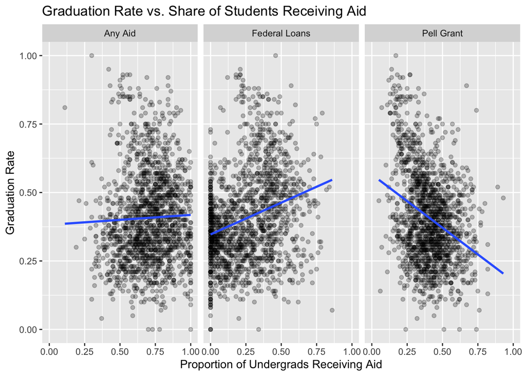

```r
ggplot(tidy_full, aes(perc, tot_grad_rt)) +
  geom_point(alpha = .25) +
  geom_smooth(method = "lm", se = FALSE, linewidth = 1) +
  facet_wrap(~ aid_type, nrow = 1) +
  labs(
    title = "Graduation Rate vs. Share of Students Receiving Aid",
    x     = "Proportion of Undergrads Receiving Aid",
    y     = "Graduation Rate"
  )
```

## 4.1 - Univariate Analysis

I want to see the distributions of the variables I have included in the full data. I will look at the distributions for the dependent variable (grad rate), the columns that represent the share of students meeting a condition, and the average aid awarded. I am not as interested in just the count of students or the total sum of aid at a college as it does not tell as complete a story as the percents do. The proportion of students receiving aid takes into consideration the total number of students and the number of students receviing aid by college.

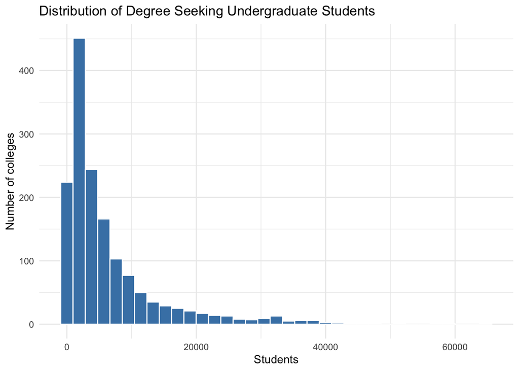

```r
ggplot(full_data, aes(x = tot_degr_ugrd)) +
  geom_histogram(bins = 35,
                 fill = "steelblue", colour = "white") +
  labs(title = "Distribution of Degree Seeking Undergraduate Students",
       x = "Students",
       y = "Number of colleges") +
  theme_minimal()
```

There is a natural floor to the number of students since there cannot be less than 0 students seeking an undergraduate degree at a college. The variable is heavily right skewed which can impact the performance of the model so we will apply a log transformation.

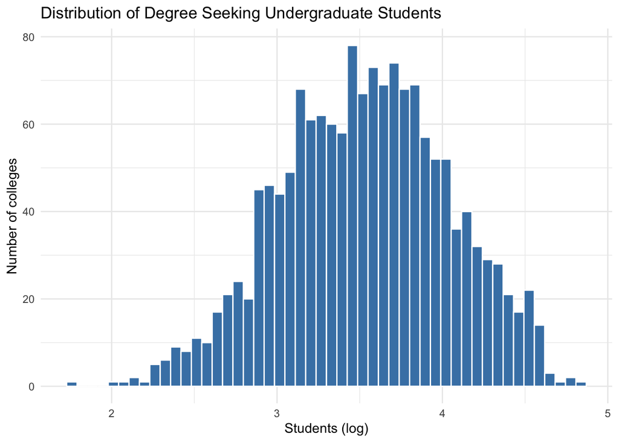

```r
ggplot(full_data, aes(x = log10(tot_degr_ugrd))) +
  geom_histogram(bins = 50,
                 fill = "steelblue", colour = "white") +
  labs(title = "Distribution of Degree Seeking Undergraduate Students",
       x = "Students (log)",
       y = "Number of colleges") +
  theme_minimal()
```

We see that this now takes on a more normal distrubution bell like shape. we will add a column for the log value

Then we look at how the dependent variable is distributed, the graduation rate. Graduation rate is slightly right skewed, but is generally bell shaped

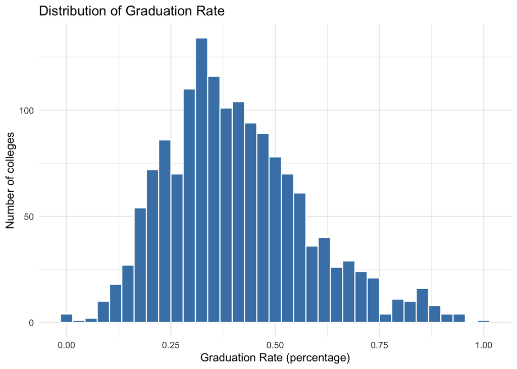

```r
ggplot(full_data, aes(x = tot_grad_rt)) +
  geom_histogram(bins = 35,
                 fill = "steelblue", colour = "white") +
  labs(title = "Distribution of Graduation Rate",
       x = "Graduation Rate (percentage)",
       y = "Number of colleges") +
  theme_minimal()
```

We have natrual ceilings and floors as you cannot offer less than 0 % of students aid, and you cannot give more than 100% of your students aid. The shape is roughly bell shaped with a left skew

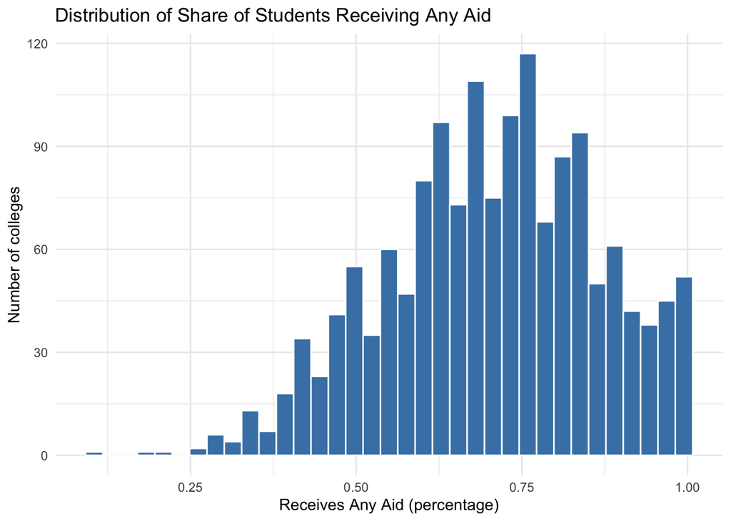

```r
ggplot(full_data, aes(x = perc_awd_any_aid)) +
  geom_histogram(bins = 35,
                 fill = "steelblue", colour = "white") +
  labs(title = "Distribution of Share of Students Receiving Any Aid",
       x = "Receives Any Aid (percentage)",
       y = "Number of colleges") +
  theme_minimal()
```

We have a nearly normal bell shape forming for this distribution of percent of students receiving pell

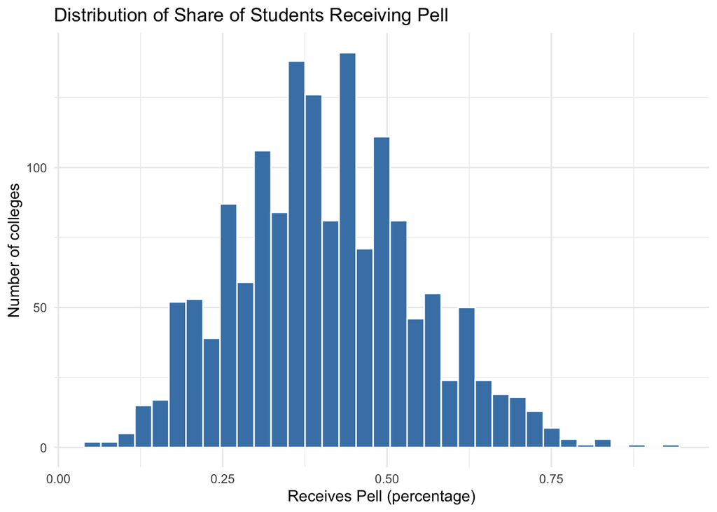

```r
ggplot(full_data, aes(x = perc_awd_pell)) +
  geom_histogram(bins = 35,
                 fill = "steelblue", colour = "white") +
  labs(title = "Distribution of Share of Students Receiving Pell",
       x = "Receives Pell (percentage)",
       y = "Number of colleges") +
  theme_minimal()
```

The percent share of loans has a heavy right skew and a large proportion at 0. This is something that will be worth taking into consideration as we build the model. It may turn out to be a characteristic that should be evaluated seperately and out of the scope of this analysis.

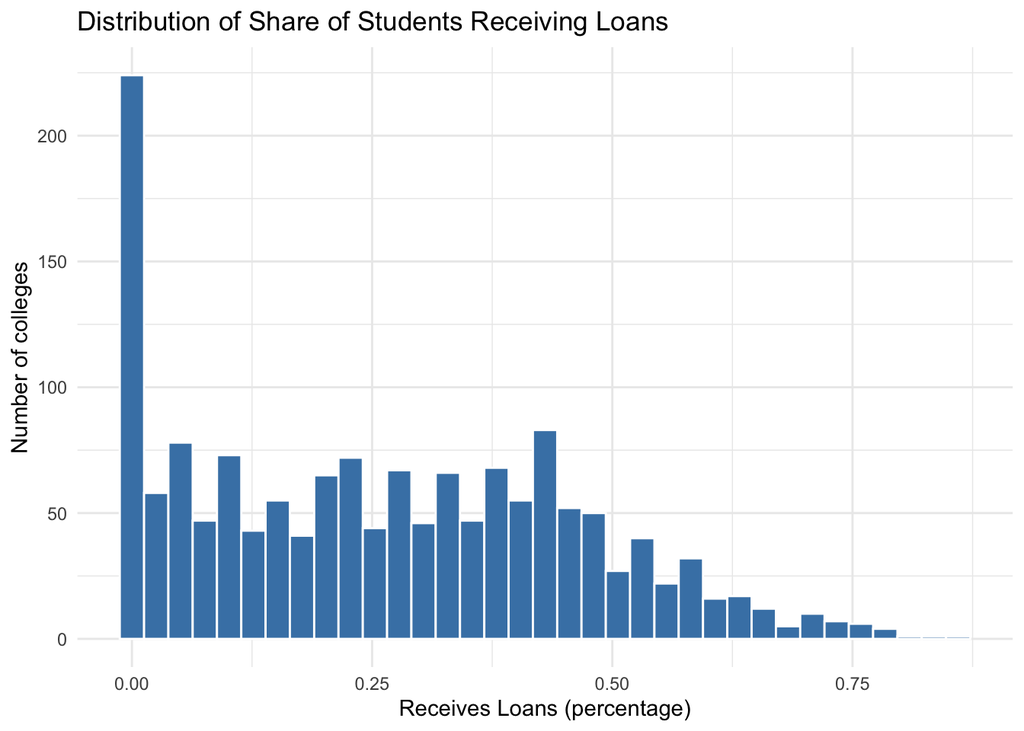

```r
ggplot(full_data, aes(x = perc_awd_loans)) +
  geom_histogram(bins = 35,
                 fill = "steelblue", colour = "white") +
  labs(title = "Distribution of Share of Students Receiving Loans",
       x = "Receives Loans (percentage)",
       y = "Number of colleges") +
  theme_minimal()
```

The data are generally right skewed, however we cannot just delete them as they may be indications of the real world and not errors. It is possible that the colleges have high cost of attendance and offer more scholarships to balance out the cost.

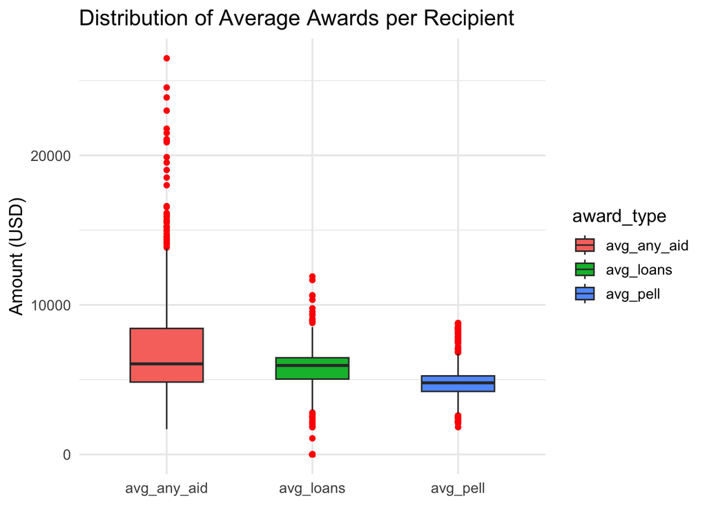

```r
full_data |>
  select(unitid = UNITID,
         avg_any_aid  = avg_awd_any_aid,
         avg_pell     = avg_awd_pell,
         avg_loans    = avg_awd_loans) |>
  pivot_longer(
    cols      = starts_with("avg_"),
    names_to  = "award_type",
    values_to = "amount"
  ) |>
  ggplot(aes(x = award_type,
             y = amount,
             fill = award_type)) +
  geom_boxplot(width = .5, outlier.colour = "red") +
  labs(title = "Distribution of Average Awards per Recipient",
       x = NULL, y = "Amount (USD)") +

  theme_minimal(base_size = 13)
```

## 4.2 - Multivariate Analysis

What relationship can be observed between the share of students receiving any aid and graduation rate? We do not see a very strong linear relationship between the proportion of students receiving aid and the graduation rate

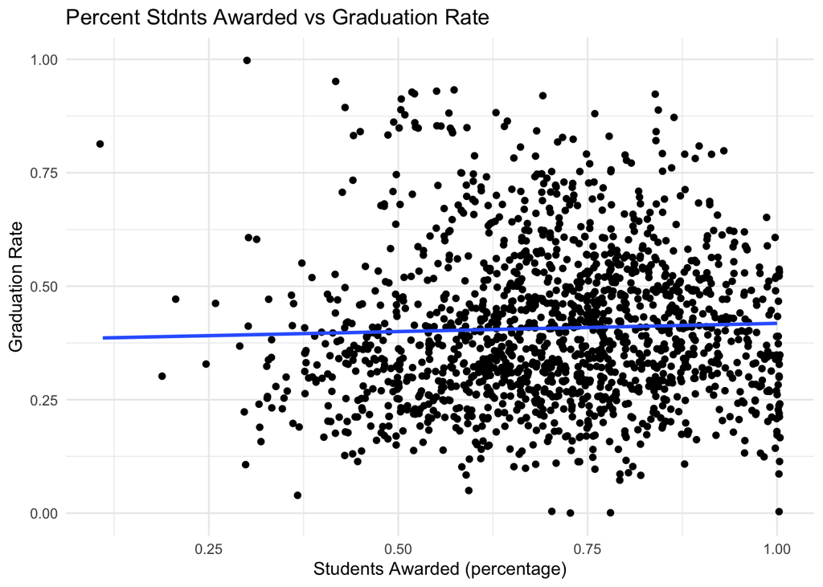

```r
ggplot(data = full_data, aes(x = perc_awd_any_aid, y = tot_grad_rt)) +
  geom_jitter() +
  stat_smooth(method = "lm", se = FALSE) +
  labs(title = "Percent Stdnts Awarded vs Graduation Rate",
       x = "Students Awarded (percentage)",
       y = "Graduation Rate") +
  theme_minimal()
```

What relationship can be observed between the average aid students received and graduation rate? Here we see a much stronger positive trending relationship between the two variables

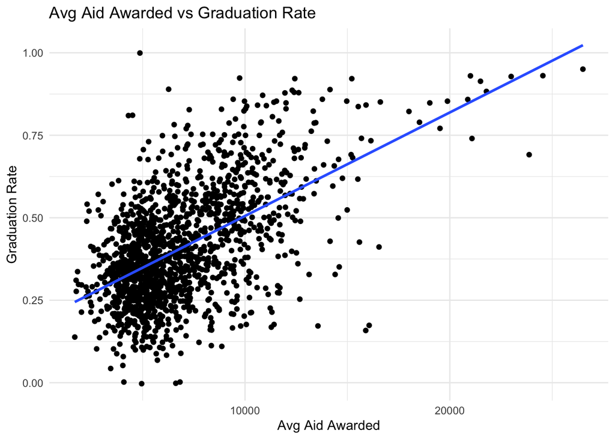

```r
ggplot(data = full_data, aes(x = avg_awd_any_aid, y = tot_grad_rt)) +
  geom_jitter() +
  stat_smooth(method = "lm", se = FALSE) +
  labs(title = "Avg Aid Awarded vs Graduation Rate",
       x = "Avg Aid Awarded",
       y = "Graduation Rate") +
  theme_minimal()
```

```r
final_data <- full_data |>
  select(sector,state,tot_grad_rt,tot_degr_ugrd,perc_awd_any_aid,avg_awd_pell,avg_awd_loans,avg_awd_any_aid,perc_awd_pell,perc_awd_loans) |>
  filter(!is.na(avg_awd_loans)) |>
  transmute(
    sector,
    state,
    tot_grad_rt,
    perc_awd_any_aid,
    perc_awd_pell,
    perc_awd_loans,
    avg_aid     = avg_awd_any_aid / 1000,
    avg_pell    = avg_awd_pell / 1000,
    avg_loans   = avg_awd_loans / 1000,
    log_tot_ugrd = log10(tot_degr_ugrd)
  )

head(final_data,5)
```

```
##           sector state tot_grad_rt perc_awd_any_aid perc_awd_pell
## 1 Public, 4‑Year    AL        0.29             0.83          0.64
## 2 Public, 4‑Year    AL        0.63             0.75          0.34
## 3 Public, 4‑Year    AL        0.62             0.69          0.23
## 4 Public, 4‑Year    AL        0.30             0.96          0.72
## 5 Public, 4‑Year    AL        0.74             0.68          0.19
##   perc_awd_loans  avg_aid avg_pell avg_loans log_tot_ugrd
## 1           0.59 11.59689  5.77489  6.733796     3.716087
## 2           0.42 10.55476  6.13531  6.788345     4.106395
## 3           0.35  9.81416  4.68933  6.441246     3.844166
## 4           0.78 10.19909  4.90675  8.423590     3.517987
## 5           0.35 15.68529  5.20234  6.233895     4.496376
```

```r
library(GGally)
```

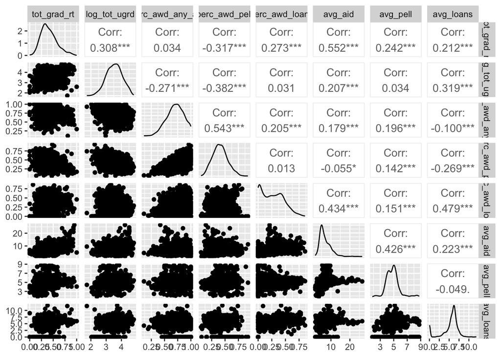

```r
corr_vars <- final_data |>
  select(
    tot_grad_rt,
    log_tot_ugrd,
    perc_awd_any_aid,
    perc_awd_pell,
    perc_awd_loans,
    avg_aid,
    avg_pell,
    avg_loans
  )

GGally::ggpairs(corr_vars)
```

# 5 - Regression Modeling

I first want to explore some simple linear regressions with the share of students receiving any aid (% of students) vs grad rate, and the depth of aid (average amount of aid recevied) vs grad rate.

```r
ipeds_lm_1 <- lm(tot_grad_rt ~ perc_awd_any_aid, data = final_data)
summary(ipeds_lm_1)
```

```
##
## Call:
## lm(formula = tot_grad_rt ~ perc_awd_any_aid, data = final_data)
##
## Residuals:
##      Min       1Q   Median       3Q      Max
## -0.41814 -0.11948 -0.02443  0.09962  0.60712
##
## Coefficients:
##                  Estimate Std. Error t value Pr(>|t|)
## (Intercept)       0.38206    0.01942  19.670   <2e-16 ***
## perc_awd_any_aid  0.03608    0.02685   1.344    0.179
## ---
## Signif. codes:  0 '***' 0.001 '**' 0.01 '*' 0.05 '.' 0.1 ' ' 1
##
## Residual standard error: 0.169 on 1533 degrees of freedom
## Multiple R-squared:  0.001177,   Adjusted R-squared:  0.000525
## F-statistic: 1.806 on 1 and 1533 DF,  p-value: 0.1792
```

The R-squared value is near 0 This model is generally not a great predictor for graduation rate

```r
ipeds_lm_2 <- lm(tot_grad_rt ~ avg_aid, data = final_data)
summary(ipeds_lm_2)
```

```
##
## Call:
## lm(formula = tot_grad_rt ~ avg_aid, data = final_data)
##
## Residuals:
##      Min       1Q   Median       3Q      Max
## -0.53038 -0.09103 -0.00393  0.08624  0.65557
##
## Coefficients:
##             Estimate Std. Error t value Pr(>|t|)
## (Intercept) 0.191682   0.009076   21.12   <2e-16 ***
## avg_aid     0.031373   0.001211   25.90   <2e-16 ***
## ---
## Signif. codes:  0 '***' 0.001 '**' 0.01 '*' 0.05 '.' 0.1 ' ' 1
##
## Residual standard error: 0.141 on 1533 degrees of freedom
## Multiple R-squared:  0.3044, Adjusted R-squared:  0.304
## F-statistic: 670.9 on 1 and 1533 DF,  p-value: < 2.2e-16
```

Next I want to move onto exploring some multiple linear regression models.

```r
ipeds_lm_3 <- lm(tot_grad_rt ~ perc_awd_any_aid + avg_aid + sector + state + log_tot_ugrd + perc_awd_pell + perc_awd_loans, data = final_data)
summary(ipeds_lm_3)
```

```
##
## Call:
## lm(formula = tot_grad_rt ~ perc_awd_any_aid + avg_aid + sector +
##     state + log_tot_ugrd + perc_awd_pell + perc_awd_loans, data = final_data)
##
## Residuals:
##      Min       1Q   Median       3Q      Max
## -0.48239 -0.07581 -0.00008  0.06834  0.72678
##
## Coefficients:
##                       Estimate Std. Error t value Pr(>|t|)
## (Intercept)           0.057931   0.066569   0.870 0.384311
## perc_awd_any_aid      0.184345   0.026177   7.042 2.89e-12 ***
## avg_aid               0.027981   0.001380  20.278  < 2e-16 ***
## sectorPublic, 4‑Year -0.008776   0.009385  -0.935 0.349855
## stateAL               0.124186   0.063496   1.956 0.050677 .
## stateAR               0.194557   0.063842   3.047 0.002349 **
## stateAZ               0.013722   0.064495   0.213 0.831544
## stateCA               0.111404   0.060843   1.831 0.067298 .
## stateCO               0.053847   0.063882   0.843 0.399412
## stateCT               0.152225   0.070714   2.153 0.031506 *
## stateDC              -0.013561   0.132699  -0.102 0.918614
## stateDE               0.041056   0.091064   0.451 0.652164
## stateFL               0.239504   0.062744   3.817 0.000141 ***
## stateGA               0.127901   0.062618   2.043 0.041272 *
## stateHI               0.122800   0.070378   1.745 0.081219 .
## stateIA               0.171571   0.066414   2.583 0.009880 **
## stateID               0.111959   0.073173   1.530 0.126214
## stateIL               0.134741   0.061954   2.175 0.029800 *
## stateIN               0.117530   0.066909   1.757 0.079201 .
## stateKS               0.208498   0.063475   3.285 0.001045 **
## stateKY               0.199434   0.065356   3.052 0.002317 **
## stateLA               0.115795   0.064798   1.787 0.074141 .
## stateMA               0.084678   0.063977   1.324 0.185852
## stateMD               0.102557   0.063968   1.603 0.109093
## stateME               0.101965   0.067808   1.504 0.132864
## stateMI               0.043068   0.062452   0.690 0.490541
## stateMN               0.159639   0.062954   2.536 0.011322 *
## stateMO               0.125657   0.064239   1.956 0.050642 .
## stateMS               0.180259   0.065491   2.752 0.005988 **
```

[output cut: 19 more lines]

```
## stateVA               0.167927   0.062993   2.666 0.007764 **
## stateVT               0.008754   0.091385   0.096 0.923695
## stateWA               0.060030   0.062170   0.966 0.334415
## stateWI               0.225549   0.063694   3.541 0.000411 ***
## stateWV               0.075837   0.065608   1.156 0.247907
## stateWY               0.104351   0.072827   1.433 0.152109
## log_tot_ugrd          0.030241   0.007919   3.819 0.000140 ***
## perc_awd_pell        -0.507952   0.031498 -16.127  < 2e-16 ***
## perc_awd_loans        0.055341   0.023194   2.386 0.017159 *
## ---
## Signif. codes:  0 '***' 0.001 '**' 0.01 '*' 0.05 '.' 0.1 ' ' 1
##
## Residual standard error: 0.1185 on 1478 degrees of freedom
## Multiple R-squared:  0.5263, Adjusted R-squared:  0.5084
## F-statistic: 29.33 on 56 and 1478 DF,  p-value: < 2.2e-16
```

I will remove a variable, starting with the percent of students that receive loans.

```r
ipeds_lm_4 <- lm(tot_grad_rt ~ perc_awd_any_aid + avg_aid + sector + state + log_tot_ugrd + perc_awd_pell , data = final_data)
summary(ipeds_lm_4)
```

```
##
## Call:
## lm(formula = tot_grad_rt ~ perc_awd_any_aid + avg_aid + sector +
##     state + log_tot_ugrd + perc_awd_pell, data = final_data)
##
## Residuals:
##      Min       1Q   Median       3Q      Max
## -0.47379 -0.07679  0.00059  0.06781  0.73679
##
## Coefficients:
##                        Estimate Std. Error t value Pr(>|t|)
## (Intercept)           0.0519299  0.0666268   0.779 0.435860
## perc_awd_any_aid      0.1881399  0.0261703   7.189 1.03e-12 ***
## avg_aid               0.0286971  0.0013490  21.273  < 2e-16 ***
## sectorPublic, 4‑Year -0.0003344  0.0087059  -0.038 0.969368
## stateAL               0.1352966  0.0634256   2.133 0.033076 *
## stateAR               0.2057312  0.0637712   3.226 0.001282 **
## stateAZ               0.0164678  0.0645869   0.255 0.798781
## stateCA               0.1113685  0.0609390   1.828 0.067820 .
## stateCO               0.0593746  0.0639413   0.929 0.353258
## stateCT               0.1629975  0.0706819   2.306 0.021244 *
## stateDC              -0.0086239  0.1328934  -0.065 0.948267
## stateDE               0.0508534  0.0911154   0.558 0.576847
## stateFL               0.2408940  0.0628409   3.833 0.000132 ***
## stateGA               0.1347728  0.0626507   2.151 0.031624 *
## stateHI               0.1258651  0.0704782   1.786 0.074325 .
## stateIA               0.1903419  0.0660511   2.882 0.004012 **
## stateID               0.1236531  0.0731244   1.691 0.091048 .
## stateIL               0.1393707  0.0620221   2.247 0.024780 *
## stateIN               0.1281417  0.0668672   1.916 0.055512 .
## stateKS               0.2226469  0.0632974   3.517 0.000449 ***
## stateKY               0.2101991  0.0653031   3.219 0.001315 **
## stateLA               0.1342787  0.0644353   2.084 0.037338 *
## stateMA               0.0996413  0.0637702   1.563 0.118383
## stateMD               0.1127101  0.0639276   1.763 0.078092 .
## stateME               0.1141748  0.0677217   1.686 0.092018 .
## stateMI               0.0524525  0.0624269   0.840 0.400920
## stateMN               0.1753116  0.0627100   2.796 0.005247 **
## stateMO               0.1351954  0.0642159   2.105 0.035431 *
## stateMS               0.1911386  0.0654353   2.921 0.003542 **
```

[output cut: 18 more lines]

```
## stateUT               0.1111228  0.0733815   1.514 0.130159
## stateVA               0.1732132  0.0630542   2.747 0.006086 **
## stateVT               0.0177906  0.0914515   0.195 0.845783
## stateWA               0.0573604  0.0622589   0.921 0.357033
## stateWI               0.2400187  0.0635054   3.780 0.000163 ***
## stateWV               0.0887331  0.0654890   1.355 0.175646
## stateWY               0.1096617  0.0729085   1.504 0.132769
## log_tot_ugrd          0.0303936  0.0079315   3.832 0.000132 ***
## perc_awd_pell        -0.5085752  0.0315466 -16.121  < 2e-16 ***
## ---
## Signif. codes:  0 '***' 0.001 '**' 0.01 '*' 0.05 '.' 0.1 ' ' 1
##
## Residual standard error: 0.1187 on 1479 degrees of freedom
## Multiple R-squared:  0.5245, Adjusted R-squared:  0.5068
## F-statistic: 29.66 on 55 and 1479 DF,  p-value: < 2.2e-16
```

We do not see a major change in the R-Squared value, and still have a statistically significant model, while trimming down on the features included.

Next I will trim down on the sector

```r
ipeds_lm_5 <- lm(tot_grad_rt ~ perc_awd_any_aid + avg_aid + state + log_tot_ugrd + perc_awd_pell , data = final_data)
summary(ipeds_lm_5)
```

```
##
## Call:
## lm(formula = tot_grad_rt ~ perc_awd_any_aid + avg_aid + state +
##     log_tot_ugrd + perc_awd_pell, data = final_data)
##
## Residuals:
##      Min       1Q   Median       3Q      Max
## -0.47400 -0.07677  0.00063  0.06777  0.73686
##
## Coefficients:
##                   Estimate Std. Error t value Pr(>|t|)
## (Intercept)       0.052031   0.066552   0.782 0.434447
## perc_awd_any_aid  0.187977   0.025814   7.282 5.33e-13 ***
## avg_aid           0.028670   0.001146  25.011  < 2e-16 ***
## stateAL           0.135532   0.063106   2.148 0.031901 *
## stateAR           0.205947   0.063503   3.243 0.001209 **
## stateAZ           0.016651   0.064389   0.259 0.795982
## stateCA           0.111631   0.060534   1.844 0.065368 .
## stateCO           0.059517   0.063811   0.933 0.351122
## stateCT           0.163150   0.070547   2.313 0.020880 *
## stateDC          -0.008603   0.132847  -0.065 0.948375
## stateDE           0.050995   0.091010   0.560 0.575343
## stateFL           0.240917   0.062817   3.835 0.000131 ***
## stateGA           0.134944   0.062471   2.160 0.030925 *
## stateHI           0.126015   0.070346   1.791 0.073439 .
## stateIA           0.190630   0.065601   2.906 0.003716 **
## stateID           0.123812   0.072982   1.696 0.090007 .
## stateIL           0.139650   0.061573   2.268 0.023471 *
## stateIN           0.128248   0.066788   1.920 0.055020 .
## stateKS           0.222884   0.062975   3.539 0.000414 ***
## stateKY           0.210467   0.064909   3.243 0.001211 **
## stateLA           0.134472   0.064217   2.094 0.036427 *
## stateMA           0.099835   0.063548   1.571 0.116392
## stateMD           0.112915   0.063683   1.773 0.076420 .
## stateME           0.114353   0.067540   1.693 0.090647 .
## stateMI           0.052669   0.062150   0.847 0.396881
## stateMN           0.175522   0.062449   2.811 0.005009 **
## stateMO           0.135398   0.063977   2.116 0.034482 *
## stateMS           0.191378   0.065116   2.939 0.003344 **
## stateMT           0.121796   0.066065   1.844 0.065447 .
```

[output cut: 17 more lines]

```
## stateUT           0.111250   0.073282   1.518 0.129204
## stateVA           0.173477   0.062659   2.769 0.005700 **
## stateVT           0.018108   0.091046   0.199 0.842373
## stateWA           0.057436   0.062207   0.923 0.355997
## stateWI           0.240164   0.063371   3.790 0.000157 ***
## stateWV           0.088898   0.065326   1.361 0.173774
## stateWY           0.109808   0.072785   1.509 0.131598
## log_tot_ugrd      0.030328   0.007745   3.916 9.42e-05 ***
## perc_awd_pell    -0.508393   0.031176 -16.307  < 2e-16 ***
## ---
## Signif. codes:  0 '***' 0.001 '**' 0.01 '*' 0.05 '.' 0.1 ' ' 1
##
## Residual standard error: 0.1187 on 1480 degrees of freedom
## Multiple R-squared:  0.5245, Adjusted R-squared:  0.5072
## F-statistic: 30.23 on 54 and 1480 DF,  p-value: < 2.2e-16
```

```r
car::vif(ipeds_lm_5)
```

```
##                      GVIF Df GVIF^(1/(2*Df))
## perc_awd_any_aid 1.874214  1        1.369019
## avg_aid          1.265029  1        1.124735
## state            2.478467 50        1.009118
## log_tot_ugrd     1.705701  1        1.306025
## perc_awd_pell    2.010798  1        1.418026
```

What happens if the state is removed? Can we compare the with and without models using an anova?

```r
ipeds_lm_6 <- lm(
  tot_grad_rt ~ perc_awd_any_aid + avg_aid +
                log_tot_ugrd + perc_awd_pell,
  data = final_data
)
summary(ipeds_lm_6)
```

```
##
## Call:
## lm(formula = tot_grad_rt ~ perc_awd_any_aid + avg_aid + log_tot_ugrd +
##     perc_awd_pell, data = final_data)
##
## Residuals:
##      Min       1Q   Median       3Q      Max
## -0.48951 -0.08609 -0.00387  0.07658  0.65970
##
## Coefficients:
##                   Estimate Std. Error t value Pr(>|t|)
## (Intercept)       0.116669   0.033422   3.491 0.000495 ***
## perc_awd_any_aid  0.170607   0.025581   6.669 3.58e-11 ***
## avg_aid           0.027183   0.001184  22.968  < 2e-16 ***
## log_tot_ugrd      0.041990   0.007228   5.810 7.60e-09 ***
## perc_awd_pell    -0.405228   0.030081 -13.471  < 2e-16 ***
## ---
## Signif. codes:  0 '***' 0.001 '**' 0.01 '*' 0.05 '.' 0.1 ' ' 1
##
## Residual standard error: 0.1296 on 1530 degrees of freedom
## Multiple R-squared:  0.4132, Adjusted R-squared:  0.4117
## F-statistic: 269.4 on 4 and 1530 DF,  p-value: < 2.2e-16
```

```r
car::vif(ipeds_lm_6)
```

```
## perc_awd_any_aid          avg_aid     log_tot_ugrd    perc_awd_pell
##         1.541813         1.129703         1.244408         1.568178
```

```r
anova(ipeds_lm_6, ipeds_lm_5)
```

```
## Analysis of Variance Table
##
## Model 1: tot_grad_rt ~ perc_awd_any_aid + avg_aid + log_tot_ugrd + perc_awd_pell
## Model 2: tot_grad_rt ~ perc_awd_any_aid + avg_aid + state + log_tot_ugrd +
##     perc_awd_pell
##   Res.Df    RSS Df Sum of Sq      F    Pr(>F)
## 1   1530 25.716
## 2   1480 20.839 50     4.877 6.9273 < 2.2e-16 ***
## ---
## Signif. codes:  0 '***' 0.001 '**' 0.01 '*' 0.05 '.' 0.1 ' ' 1
```

Based on the Anova results, the state variable captures significant unique signal, so it would be better to keep the state included.

# 6 - Model Diagnostics

Below we plot the residuals of the model in a historgram and observe that there are nearly normal residuals. This assumption is satisfied.

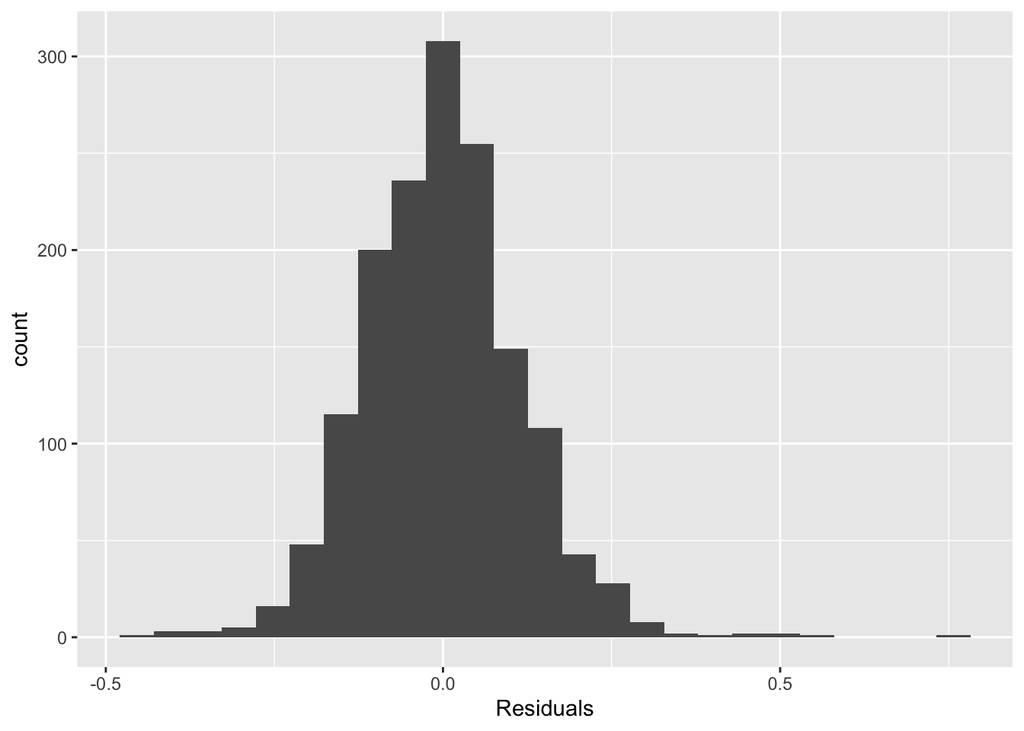

```r
ggplot(data = ipeds_lm_5, aes(x = .resid)) +
  geom_histogram(bins = 25) +
  xlab("Residuals")
```

Most of our residuals below fall on a line, and are nearly normal, however we do see for some values on both extremes a tail that trails off. The model may not be as reliable when handling those extreme values.

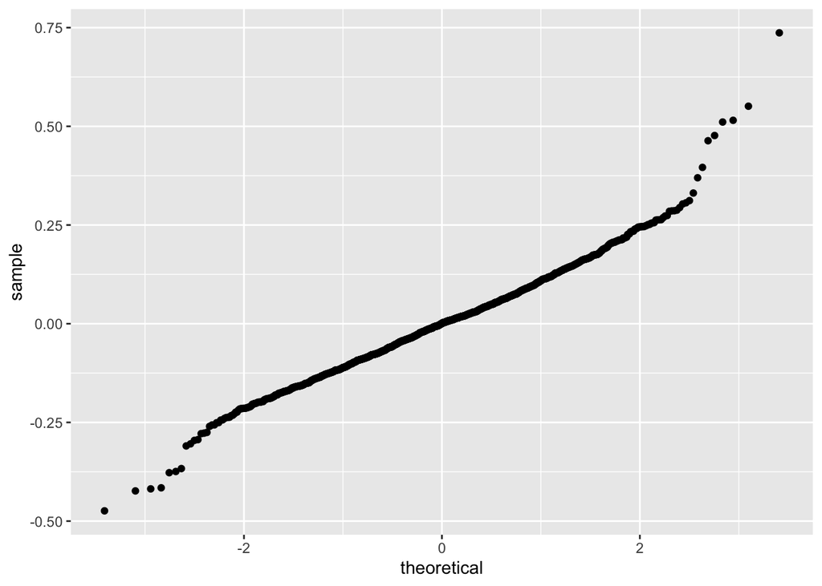

```r
ggplot(data = ipeds_lm_5, aes(sample = .resid)) +
  stat_qq()
```

Here we do not see any major patterns but there are observed outliers again and a denser cloud around .3 - .5. The assumption is mildly violated but generally still seems to hold. It may be worth looking into this further in future analysis.

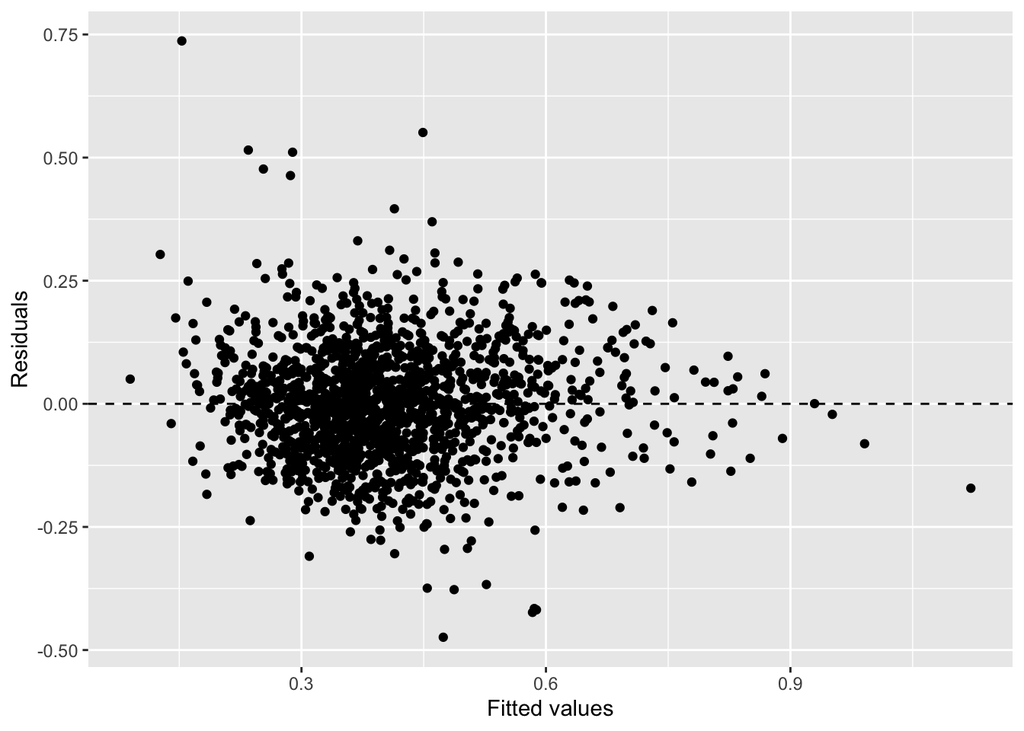

```r
ggplot(data = ipeds_lm_5, aes(x = .fitted, y = .resid)) +
  geom_point() +
  geom_hline(yintercept = 0, linetype = "dashed") +
  xlab("Fitted values") +
  ylab("Residuals")
```

# 7 - Conclusions

The final model chosen uses the proportion of students awarded any aid, the average aid amount by student, the percent of students that receive Pell, the state of the college, and the total number of students as predictors for the colleges total graduation rate.

For every $1000 increase in the average aid awarded, it is expected that the graduation rate would rise 2.9 percentage points.

For every 10 percentage point increase in proportion of students that recevive aid attributes to 2 percentage point gain in graduation rate.

Overall, the breadth of aid (proportion of students awarded) along with the depth (average aid package amount) are strongly associated with student success(graduation rate) when factoring in State effects, proportion of pell recipients, and student count.

# 8 - Further Considerations

It is important to note that there can be underlying factors which are influencing the results, such as net price, types of aid offered (Predominantly private scholarships, state aid, institutional scholarships? etc), admissions criteria and more that may better explain fluctuations in graduation rate. Further considerations may also be given to the data itself, are the outliers a result of error or do they truly represent the real world? What types of events may have influenced the data, for example would the years reported have accounted for any aid provided to aid with pandemic related issues, are the admissions or enrollment data influenced by post pandemic effects?